# Unit 4 Lesson 2 PCHiC data processing

Csilla Varnai

2022-08-18

You will be working with chromatin interactions in primary blood cells, identified by Javierre et al. This is the file that was released with the publication. In this exercise, we will study the dataset to identify if chromatin interactions are cell type specific.

## 1. Input files and data processing

### Read and inspect the chromatin interaction data

First, let us read the input data, and interpret what is stored in each column. The columns of the file contain the following information:

- **baitChr**, **baitStart**, **baitEnd**: the promoter containing fragment’s genomic coordinates,
- **baitID**: the promoter containing fragment’s unique ID,
- **baitName**: the names of promoters overlapping the restriction fragment,
- **oeChr**, **oeStart**, **oeEnd**: the genomic coordinates of the other end of the interaction,
- **oeID**: the unique ID of the other end
- **oeName**: the names of promoters overlapping the other end,
- **dist**: the genomic distance between the promoter containing fragment and the other end
- **Mon**, **Mac0**, **Mac1**, **Mac2**, **Neu**, **MK**, **EP**, **Ery**, **FoeT**, **nCD4**, **tCD4**, **aCD4**, **naCD4**, **nCD8**, **tCD4**, **nB**, **tB**: interaction scores for the cell types as identified by the CHiCAGO software package.
- **clusterID**, **clusterPostProb**: cluster ID and posterior probability from the clustering in Javierre et al. (2016), you will not need these for the assignment.

```r
interactions = as.data.frame(read.table("PCHiC_peak_matrix_cutoff5.txt", header = TRUE))
head(interactions)
```

```
##   baitChr baitStart baitEnd baitID                 baitName oeChr oeStart
## 1       1    831895  848168    218 RP11-54O7.16;RP11-54O7.1     1  850619
## 2       1    831895  848168    218 RP11-54O7.16;RP11-54O7.1     1  874082
## 3       1    831895  848168    218 RP11-54O7.16;RP11-54O7.1     1  889424
## 4       1    831895  848168    218 RP11-54O7.16;RP11-54O7.1     1  903641
## 5       1    831895  848168    218 RP11-54O7.16;RP11-54O7.1     1 1206874
## 6       1    831895  848168    218 RP11-54O7.16;RP11-54O7.1     1 1239426
##     oeEnd oeID                                       oeName   dist         Mon
## 1  874081  220                AL645608.1;RP11-54O7.3;SAMD11  22319 25.54656791
## 2  876091  221                                            .  35055  1.93228469
## 3  903640  223                         KLHL17;NOC2L;PLEKHN1  56501  4.92356509
## 4  927394  224                             C1orf170;PLEKHN1  75486  5.05024812
## 5 1212438  254                          RP5-902P8.10;UBE2J2 369625  3.95344924
## 6 1278099  257 ACAP3;CPSF3L;GLTPD1;PUSL1;RP5-890O3.9;TAS1R3 418731  0.06094997
##        Mac0       Mac1       Mac2        Neu          MK        EP       Ery
```

[output cut: 20 more lines]

Let us also count the total number of interactions in the dataset.

```r
nrow(interactions)
```

```
## [1] 728838
```

### Identify the number of significant interactions

How would you identify the number of significant interactions for Monocytes (Mon), M0 Macrophages (Mac0), naive CD4+ T cells (nCD4) and naive CD8+ T cells (nCD8).

The number of significant interactions for Monocytes:

```r
sum(interactions$Mon >= 5)
```

```
## [1] 171431
```

The number of significant interactions for M0 Macrophages:

```r
sum(interactions$Mac0 >= 5)
```

```
## [1] 185701
```

The number of significant interactions for naive CD4+ T cells:

```r
sum(interactions$nCD4 >= 5)
```

```
## [1] 219440
```

The number of significant interactions for naive CD8+ T cells:

```r
sum(interactions$nCD8 >= 5)
```

```
## [1] 224390
```

### Extract the significant interactions for the Monocytes (Mon), M0 Macrophages (Mac0), naïve CD4+ T cells (nCD4) and naïve CD8+ T cells (nCD8)

Open the data wrangling cheatsheet, and find the function that can be used to extract the interactions (rows) that have an interaction score of >= 5 in Monocytes. Use the function, and save the filtered data in a data.frame named **Mon_interactions**.

```r
?filter()
```

```
## Help on topic 'filter' was found in the following packages:
##
##   Package               Library
##   dplyr                 /Library/Frameworks/R.framework/Versions/4.2/Resources/library
##   stats                 /Library/Frameworks/R.framework/Versions/4.2/Resources/library
##
##
## Using the first match ...
```

```r
Mon_interactions <- interactions %>% filter(Mon >= 5)
nrow(Mon_interactions)
```

```
## [1] 171431
```

Do the same for Macrophages (Mac0), naive CD4+ T cells (nCD4) and naive CD8+ T cells (nCD8).

```r
Mac0_interactions <- interactions %>% filter(Mac0 >= 5)
nCD4_interactions <- interactions %>% filter(nCD4 >= 5)
nCD8_interactions <- interactions %>% filter(nCD8 >= 5)
```

### Convert the data to the BEDPE file format

Using the data wrangling cheatsheet, find the function that can be used to extract the columns that are necessary for the BEDPE format. and save it in a data.frame named **Mon_interactions_bedpe**.

```r
Mon_interactions_bedpe = Mon_interactions %>% select(c(baitChr, baitStart, baitID, oeChr, oeStart, oeEnd, baitID, Mon))
head(Mon_interactions_bedpe)
```

```
##   baitChr baitStart baitID oeChr oeStart   oeEnd       Mon
## 1       1    831895    218     1  850619  874081 25.546568
## 2       1    831895    218     1  903641  927394  5.050248
## 3       1    927395    225     1 1206874 1212438  8.938573
## 4       1    943677    228     1  903641  927394  5.414854
## 5       1    943677    228     1 1206874 1212438  6.460881
## 6       1   1005127    234     1  903641  927394  8.656857
```

Do the same for Macrophages (Mac0), naive CD4+ T cells (nCD4) and naive CD8+ T cells (nCD8).

```r
Mac0_interactions_bedpe = Mac0_interactions %>% select(c(baitChr, baitStart, baitID, oeChr, oeStart, oeEnd, baitID, Mac0))
nCD4_interactions_bedpe = nCD4_interactions %>% select(c(baitChr, baitStart, baitID, oeChr, oeStart, oeEnd, baitID, nCD4))
nCD8_interactions_bedpe = nCD8_interactions %>% select(c(baitChr, baitStart, baitID, oeChr, oeStart, oeEnd, baitID, nCD8))
```

### Write data to file

Using the **write.table()** function, write the Monocyte interactions in BEDPE format into a file named **Mon.bedpe**. Look up the help page for the function, to identify the arguments you need to use. For IGV to read the files, you will have to

- set the separator to the Tab character,
- not to use quotes around the printed fields,
- not write row names and
- not write column names.

```r
?write.table()
```

```r
write.table(Mon_interactions_bedpe, file = "Mon.bedpe", append = FALSE, quote = FALSE, sep = "\t", row.names = FALSE, col.names = FALSE)
```

Write the significant interactions of Macrophages (Mac0) into the file **Mac0.bedpe**.

```r
write.table(Mac0_interactions_bedpe, file = "Mac0.bedpe", append = FALSE, quote = FALSE, sep = "\t", row.names = FALSE, col.names = FALSE)
```

Write the significant interactions of naive CD4+ T cells (nCD4) into the file **nCD4.bedpe**.

```r
write.table(nCD4_interactions_bedpe, file = "nCD4.bedpe", append = FALSE, quote = FALSE, sep = "\t", row.names = FALSE, col.names = FALSE)
```

Write the significant interactions of naive CD8+ T cells (nCD8) into the file **nCD8.bedpe**.

```r
write.table(nCD8_interactions_bedpe, file = "nCD8.bedpe", append = FALSE, quote = FALSE, sep = "\t", row.names = FALSE, col.names = FALSE)
```

### Now return to the task instructions to see your next task.

## 2. Clustering contact data

We will cluster the cell types, using the pairwise similarities of their interaction scores for all interactions called genome-wide by Javierre et al. First, we need to calculate the similarity matrix containing pairwise similarities of the celltypes, using the dist() function. The input of this function is a matrix containing the interaction scores for the cell types (columns 12 to 28).

```r
pairwise_similarity_matrix <- dist(t(interactions[,12:28]))
```

We will perform hierarchical clustering on the interaction scores, using the hclust() function. Look at the help page of the hclust() function, to see what it does and what its input parameters are. Briefly, hclust() groups together similar objects, and the more similar they are, the closer they appear in the output cluster tree named dendrogram. Feel free to play with the parameters, to see how the results change.

```r
hc <- hclust(pairwise_similarity_matrix, method = "complete")
```

Finally, let’s plot the dendrogram (cluster tree) using the plot() function. Celltypes that have more similar interaction score profiles appear closer in the tree.

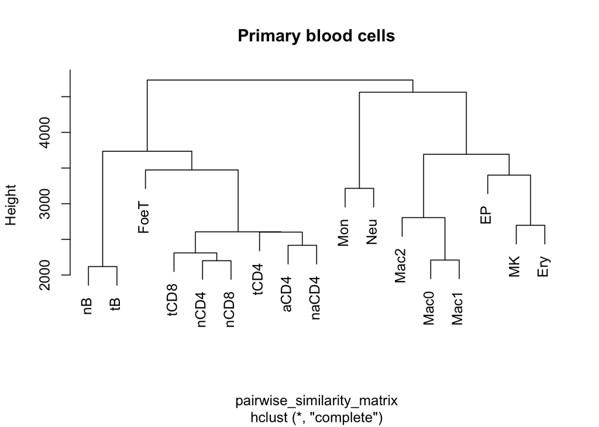

```r
plot(hc, main = "Primary blood cells")
```

Let’s save this plot.

```r
pdf("dendrogram.pdf", width = 8, height = 6)
plot(hc, main = "Primary blood cells")
dev.off()
```